# 03_Diagnostics_Respecification

Ian Douglas

12/15/2019

```r
require(car)
require(tidyverse)
require(pscl)
require(MASS)
model = readRDS("../../output/interactionModel_TWOGrp.rds")
```

```r
# convert from Tibble to data.frame
df = as.data.frame(readRDS("../../data/processed/modelData.rds")) # output of wrangling script
rownames(df) <- df$idnum
# finally, delete the rows for whom there are NA in the outcome column (only)
df = df %>%
  filter(!is.na(target))
```

# Diganostics

## Analyze the constant variance assumption

```r
pdf(width = 12, height = 7.5, file = "../../plots/fitted.X.residualPlot_OLS.pdf")
plot(model$fitted.values, model$residuals, type = "h",
     main = "Fitted Values - Residuals Plot", col = 2,
     xlab = "Fitted Values", ylab = "Residuals")
abline(h = 0, lty = 3, col="grey")
par(new=TRUE)
plot(model$fitted.values, model$residuals, cex = .5,
     xlab = "Fitted Values", ylab = "Residuals")
dev.off()
```

[figure not shown]

## QQ-plot of the OLS residuals:

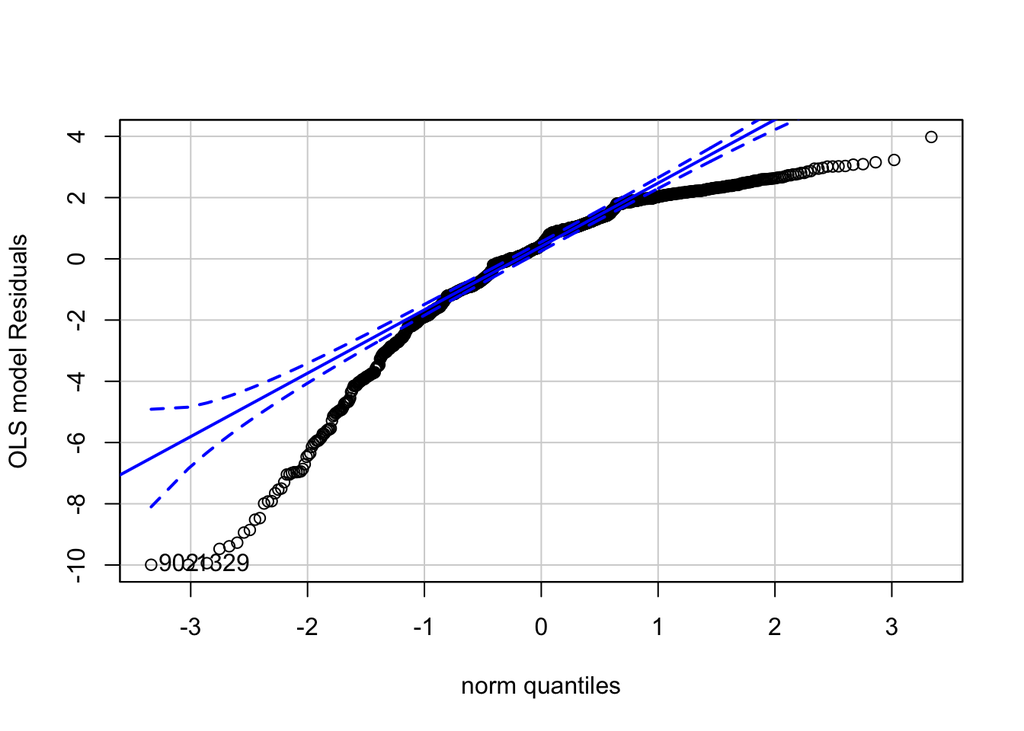

```
##  902 1329
##  576  835
```

```r
qqPlot(model$resid, ylab = "OLS model Residuals")
```

Conclusions: There is a very small fraction of outliers relative to the sample size. As a result these participants will be dropped before fitting the model again. Second, the variance appears to decline with higher values of $\hat{Y_i}$. The variance is also extremely negatively skewed.

## Mathematically analyze heteroscedasticity

```r
df = df %>%
  mutate(targetQuantile =
           factor(cut(target, quantile(target, probs=c(0, .33, .66, 1)),
                      include.lowest = TRUE),
                  labels = c("low","med","high")))
df %>% group_by(targetQuantile) %>%
  summarize_at(vars(target),
               list("mean"=mean,"var"=var,"n"=length,
                    "equalMin"= ~sum(. == min(df$target)),
                    "equalMax" = ~sum(. == max(df$target))))
```

```
## # A tibble: 3 x 6
##   targetQuantile  mean   var     n equalMin equalMax
##   <fct>          <dbl> <dbl> <int>    <int>    <int>
## 1 low             11.3 4.15    675        7        0
## 2 med             14.5 0.252   732        0        0
## 3 high            16   0       459        0      459
```

This reveals the (potentially: only) issue. The entire highest third of the data have responded to the survey by choosing the highest score possible. Therefore, the modelling approach will change to account for the probability of choosing the highest score on the survey.

# Fit the zero-inflated model

To control for the ceiling effect by which participants were much more likely to select the maximum response on the survey, I will reverse code the sums so that they reflect a new construct that will be positively skewed (rather than negatively skewed), and then offset by a constant so that the minimum is zero. It will thus represent **dis**-connection at school, rather than connectedness, and follow a zero-inflated Poisson distribution. As such, my modeling approach will include a zero-inflated negative binomial model.

## Transforming the target variable:

```r
df2 = df %>%
  # subtracting the maximum will reverse code it and shift the minimum to zero.
  mutate(disconnection = 16 - round(target)) # round to ensure no non-positive vals
rownames(df2) <- df2$idnum
```

## Check that the correlations have been reversed:

```r
cor(df2$disconnection, df2$target, use = 'complete.obs') # should be -1
```

```
## [1] -0.9999887
```

```r
# the continuous predictor
cor.test(df2$disconnection, df2$internalizingSum, use = "complete.obs")
```

```
##
##  Pearson's product-moment correlation
##
## data:  df2$disconnection and df2$internalizingSum
## t = 3.5703, df = 1200, p-value = 0.0003706
## alternative hypothesis: true correlation is not equal to 0
## 95 percent confidence interval:
##  0.04624921 0.15814933
## sample estimates:
##       cor
## 0.1025236
```

```r
# the year9 observation of outcome (to control for)
cor.test(df2$disconnection, df2$yr9_CNCT_Sum, use = "complete.obs")
```

```
##
##  Pearson's product-moment correlation
##
## data:  df2$disconnection and df2$yr9_CNCT_Sum
## t = -5.782, df = 1743, p-value = 8.731e-09
## alternative hypothesis: true correlation is not equal to 0
## 95 percent confidence interval:
##  -0.18293089 -0.09084312
## sample estimates:
##        cor
## -0.1371834
```

## Visualize the new distribution:

```r
#plot.window(xlim = c(0,4), ylim = c(0,.4), xaxs="i")
pdf(file="../../plots/aggregateDisconnectDensity.pdf",
    height = 8, width = 12)
plot(density(df2$disconnection, from = min(df2$disconnection),
             to = max(df2$disconnection), bw = .7, kernel = 'g'),
     main="Aggregate Distribution of Disconnectedness", xaxs = "i")
abline(v = mean(df2$disconnection), lty = 2)
text(x = mean(df2$disconnection), y = .075,
     labels = expression(bar("Y")), pos = 4)
dev.off()
```

[figure not shown]

## Fit the zero inflated model

```r
zeroInflMod = zeroinfl(
  disconnection ~ yr9_CNCT_Sum + internalizingSum*avoidant | 1,
  data = df2, na.action = na.omit, dist = 'negbin'
)
summary(zeroInflMod)
```

```
##
## Call:
## zeroinfl(formula = disconnection ~ yr9_CNCT_Sum + internalizingSum *
##     avoidant | 1, data = df2, na.action = na.omit, dist = "negbin")
##
## Pearson residuals:
##     Min      1Q  Median      3Q     Max
## -1.0817 -0.9026 -0.1713  0.4574  4.8164
##
## Count model coefficients (negbin with log link):
##                            Estimate Std. Error z value Pr(>|z|)
## (Intercept)                0.898147   0.143869   6.243 4.30e-10 ***
## yr9_CNCT_Sum              -0.025002   0.007661  -3.264  0.00110 **
## internalizingSum           0.024484   0.009226   2.654  0.00796 **
## avoidant                  -0.668339   0.683951  -0.977  0.32848
## internalizingSum:avoidant  0.078362   0.064029   1.224  0.22101
## Log(theta)                 0.698987   0.155128   4.506 6.61e-06 ***
##
## Zero-inflation model coefficients (binomial with logit link):
##             Estimate Std. Error z value Pr(>|z|)
## (Intercept)   -3.161      0.829  -3.814 0.000137 ***
## ---
## Signif. codes:  0 '***' 0.001 '**' 0.01 '*' 0.05 '.' 0.1 ' ' 1
##
## Theta = 2.0117
## Number of iterations in BFGS optimization: 25
## Log-likelihood: -2332 on 7 Df
```

## Evaluate the residuals

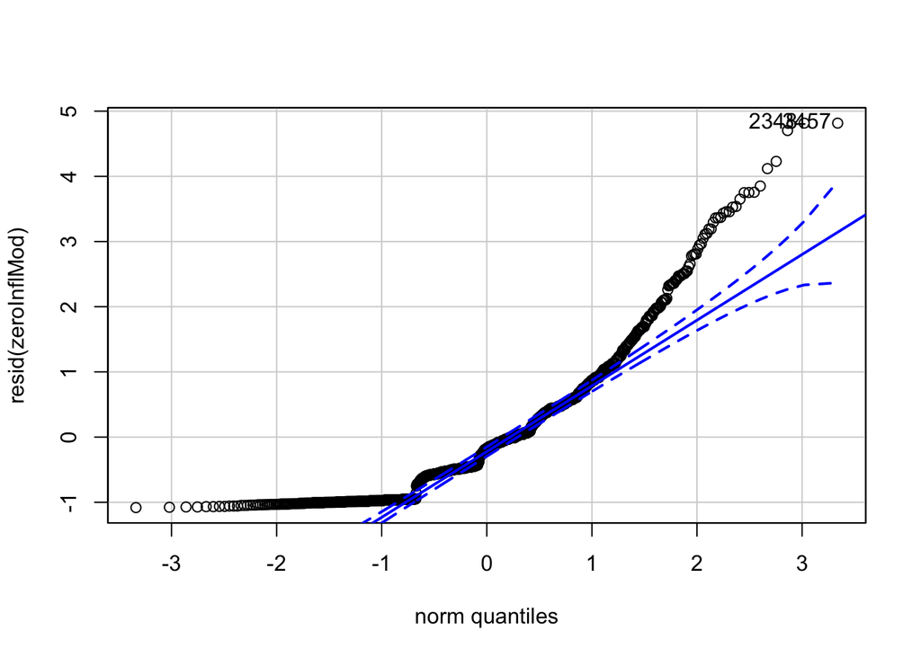

```
## 2348 3457
##  576  835
```

```r
qqPlot(resid(zeroInflMod))
```

## Two part model

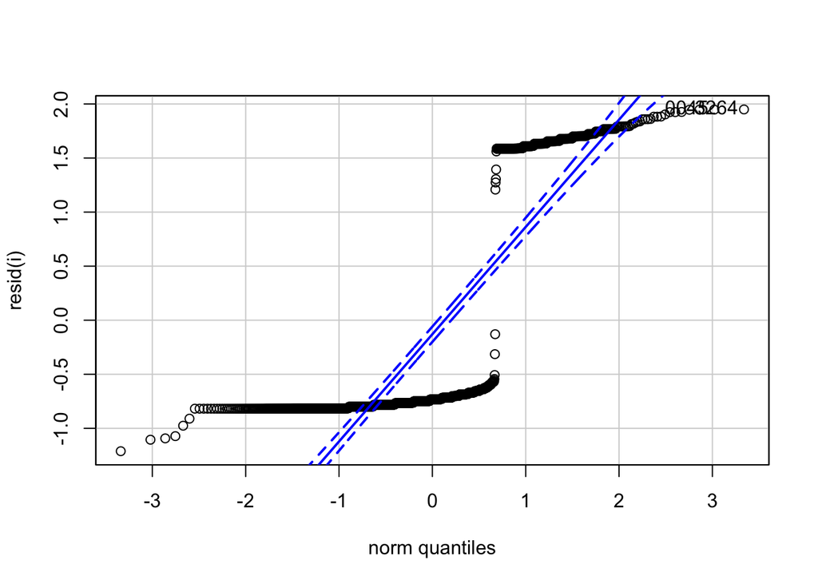

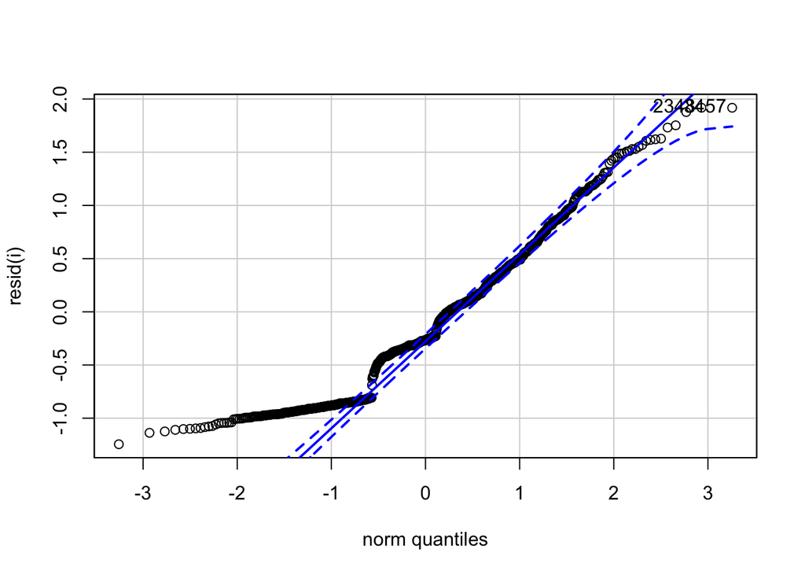

````r
hurdle_fn = function(data) {
  dat = na.omit(dplyr::select(data, disconnection,
                              yr9_CNCT_Sum, internalizingSum, avoidant))
  # Part 1: model the zeroes
  dat$is_min <- ifelse(dat$disconnection == min(dat$disconnection), 1, 0)
  part1 = glm(is_min ~ yr9_CNCT_Sum + internalizingSum*avoidant,
              data = dat, family = 'binomial')
  part2 = glm(disconnection ~ yr9_CNCT_Sum + internalizingSum * avoidant,
              data = subset(dat, is_min == 0),
              family = Gamma(link = log))
  return(list(
    zeroMod = part1,
    countMod = part2
  ))
}

twopm = hurdle_fn(df2)
#```


## Evaluate the fit
#```{r}
for (i in twopm) {
  qqPlot(resid(i))
}
````

## Compare the log likelihood of each model

```r
data.frame("log_Likelihood" = c(as.numeric(logLik(model)), as.numeric(logLik(zeroInflMod)),
           logLik(twopm[[1]]), as.numeric(logLik(twopm[[2]]))),
           "mod" =c("Lin.Reg","zero-Infl","Binom+Gamma","Binom+Gamma")) %>%
  group_by(mod) %>%
  summarize_at(vars(log_Likelihood), sum)
```

```
## # A tibble: 3 x 2
##   mod         log_Likelihood
##   <fct>                <dbl>
## 1 Binom+Gamma         -2364.
## 2 Lin.Reg             -2647.
## 3 zero-Infl           -2332.
```

## Boxcox transformation and model respecification.

```r
# Do this for the two-part model since the OLS model was much worse than others.
bc_twopm = boxcox(twopm[[2]], lambda = seq(-3,3))
```

[figure not shown]

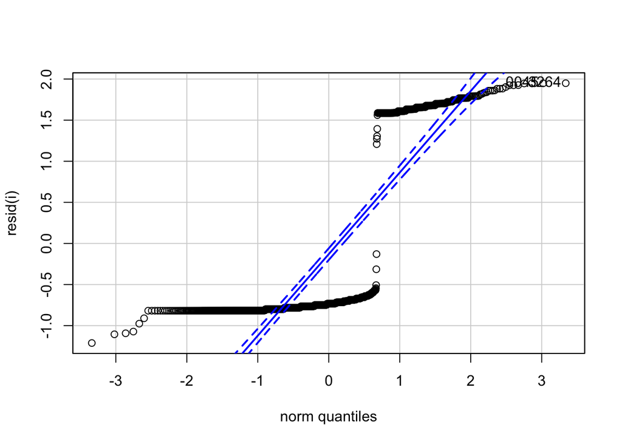

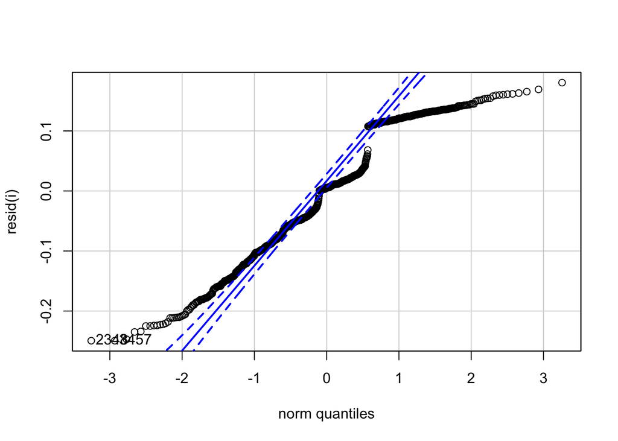

````r
best_lambda = bc_twopm$x[which.max(bc_twopm$y)]

bc.hurdle = function(data) {
  dat = na.omit(dplyr::select(data, disconnection,
                              yr9_CNCT_Sum, internalizingSum, avoidant))
  # Part 1: model the zeroes
  dat$is_min <- ifelse(dat$disconnection == min(dat$disconnection), 1, 0)
  part1 = glm(is_min ~ yr9_CNCT_Sum + internalizingSum*avoidant,
              data = dat, family = 'binomial')
  part2 = glm(disconnection^best_lambda ~ yr9_CNCT_Sum + internalizingSum * avoidant,
              data = subset(dat, is_min == 0),
              family = Gamma(link = log))
  return(list(
    zeroMod = part1,
    countMod = part2
  ))
}

bc.twopm = bc.hurdle(df2)
#```


## Evaluate the fit
#```{r}
for (i in bc.twopm) {
  qqPlot(resid(i))
}
````

## Results

```r
allModels = list(model, zeroInflMod, twopm[[1]], twopm[[2]], bc.twopm[[1]], bc.twopm[[2]])
aic <- function(fit){
  k <- length(unlist(fit$coefficients)) - 1
  n <- nrow(na.omit(fit$model))
  lgLik <- logLik(fit)[1]
  out <- -2 * lgLik + 2 * k
  return (out)
}
bic <- function(fit){
  k <- length(unlist(fit$coefficients)) - 1
  n <- nrow(na.omit(fit$model))
  lgLik <- logLik(fit)[1]
  out <- -2 * lgLik + log(n) * k
  return (out)
}

data.frame("AIC" = sapply(allModels, aic),
           "BIC" = sapply(allModels, bic),
           "mod" = c("OLS","zeroInfl","Binom","Gamma",
                    "bc.Binom","bc.Gamma"))
```

```
##         AIC       BIC      mod
## 1  5302.051  5322.368      OLS
## 2  4674.638  4700.034 zeroInfl
## 3  1333.487  1353.804    Binom
## 4  3410.654  3429.819    Gamma
## 5  1333.487  1353.804 bc.Binom
## 6 -1780.664 -1761.499 bc.Gamma
```

## Plot of the residuals against the fitted values

```r
#pdf(height = 8, width = 11, file="../../plots/resids.X.fittedsTwoPartMod.pdf")
plot(bc.twopm[[2]]$fitted.values,bc.twopm$countMod$residuals,type="h",col=2,
     xlab = "Fitted Values", ylab = "Residuals",
     main = "Fitted Values - Residuals Plot")
abline(h=mean(bc.twopm$countMod$residuals), col="grey", lty=3)
par(new=TRUE)
plot(bc.twopm[[2]]$fitted.values,bc.twopm$countMod$residuals,
     xlab = "Fitted Values", ylab = "Residuals")
#dev.off()
```

[figure not shown]

## Plot the QQ-plot for the residuals

```r
pdf(height = 8, width = 11, file="../../plots/qqplotTwoPartModBoxCox.pdf")
qqPlot(bc.twopm[[2]]$residuals, ylab = "Residuals from Two-Part Model (Box-Cox)")
```

```
## 2348 3457
##  449  629
```

```r
dev.off()
```

[figure not shown]